# Introduction to Computer Vision: Plant Seedlings Classification

## Problem Statement

### Context

In recent times, the field of agriculture has been in urgent need of modernizing, since the amount of manual work people need to put in to check if plants are growing correctly is still highly extensive. Despite several advances in agricultural technology, people working in the agricultural industry still need to have the ability to sort and recognize different plants and weeds, which takes a lot of time and effort in the long term. The potential is ripe for this trillion-dollar industry to be greatly impacted by technological innovations that cut down on the requirement for manual labor, and this is where Artificial Intelligence can actually benefit the workers in this field, as **the time and energy required to identify plant seedlings will be greatly shortened by the use of AI and Deep Learning.** The ability to do so far more efficiently and even more effectively than experienced manual labor, could lead to better crop yields, the freeing up of human inolvement for higher-order agricultural decision making, and in the long term will result in more sustainable environmental practices in agriculture as well.

### Objective

The aim of this project is to Build a Convolutional Neural Netowrk to classify plant seedlings into their respective categories.

### Data Dictionary

The Aarhus University Signal Processing group, in collaboration with the University of Southern Denmark, has recently released a dataset containing **images of unique plants belonging to 12 different species.**

- The dataset can be download from Olympus.
- The data file names are:
  - images.npy
  - Labels.csv
- Due to the large volume of data, the images were converted to the images.npy file and the labels are also put into Labels.csv, so that you can work on the data/project seamlessly without having to worry about the high data volume.
- The goal of the project is to create a classifier capable of determining a plant's species from an image.

**List of Species**

- Black-grass
- Charlock
- Cleavers
- Common Chickweed
- Common Wheat
- Fat Hen
- Loose Silky-bent
- Maize
- Scentless Mayweed
- Shepherds Purse
- Small-flowered Cranesbill
- Sugar beet

### **Note: Please use GPU runtime on Google Colab to execute the code faster.**

## Importing necessary libraries

```python
# Installing the libraries with the specified version.
# uncomment and run the following line if Google Colab is being used
!pip install tensorflow==2.15.0 scikit-learn==1.2.2 seaborn==0.13.1 matplotlib==3.7.1 numpy==1.25.2 pandas==1.5.3 opencv-python==4.8.0.76 -q --user
```

**Note**: *After running the above cell, kindly restart the notebook kernel and run all cells sequentially from the start again.*

```python
# Library for randomly selecting data points
import random

# Library for performing numerical computations
import numpy as np

# to work with dataframes
import pandas as pd

# Library for creating and showing plots
import matplotlib.pyplot as plt
import seaborn as sns

# Library for reading and showing images
import matplotlib.image as mpimg

# Main libraries for building Neural Networks
import tensorflow as tf
import keras

# To clear backend history
from keras import backend

# Keras Sequential Model
from keras import Sequential, Model

# Importing all the different layers and optimizers
from keras.optimizers import Adam,SGD
from keras.layers import Dense, Dropout, Flatten, Conv2D, MaxPooling2D, BatchNormalization, Activation, LeakyReLU
# Importing callbacks to improve model performance
from keras.callbacks import ReduceLROnPlateau, EarlyStopping, ModelCheckpoint

# Libraries for preprocessing data
import cv2
from keras.preprocessing.image import ImageDataGenerator
from sklearn.preprocessing import LabelBinarizer

# to split data into train and test
from sklearn.model_selection import train_test_split
# to generate class weights
from sklearn.utils import class_weight

# The below code can be used to ignore the warnings that may occur due to deprecations
import warnings
warnings.filterwarnings("ignore")
```

## Loading the dataset

```python
# Uncomment and run the below code if you are using google colab
from google.colab import drive
drive.mount('/content/drive')
```

Our data is separated into two different files due to its size: the images in a NumPy array and their respective labels in a CSV file. These two files represent our X and Y variables. Due to its different file type, we will open them using two diferent methods with the same functionality.

```python
# loading the dataset via the file and its directory
folder_path = '/content/drive/MyDrive/AI-ML Post Graduate/Data Documents/'

# Loading the first file
file_name = 'Labels.csv'
labels = pd.read_csv(folder_path+file_name)

# Loading the second file
file_name = 'images.npy'
images_arr = np.load(folder_path+file_name)
```

## Data Overview

Let us observe the contents of the file themselves before analyzing its content.

```python
# Getting 3 images from the Numpy Array "images_arr"
images_arr[:2, :]
```

[output not shown]

[output cut: 45 more lines]

[output not shown]

```python
# Let us look at the labels dataframe on random rows
labels.sample(12)
```

|  | Label |
| --- | --- |
| 574 | Fat Hen |
| 2468 | Cleavers |
| 1910 | Common Chickweed |
| 808 | Fat Hen |
| 3012 | Scentless Mayweed |
| 4190 | Loose Silky-bent |
| 1117 | Shepherds Purse |
| 978 | Shepherds Purse |
| 1861 | Common Chickweed |
| 2038 | Charlock |
| 2079 | Charlock |
| 638 | Fat Hen |

The images are stored in a Numpy array as interger values in different dimensions. The labels are the string value in the same index as the images counterpart, thus linking the two together. Let's looks at its dimensions.

### Understand the shape of the dataset

```python
# Extracting the parameters to which we will describe the dataset
rows, width, height, channel = images_arr.shape; label_size = labels.shape[0]; type_label = labels.nunique()[0];

# printing the results
print(f"There are {rows} images, with a size of {width} by {height} in {channel} channels. There are {label_size} labels in total, which are divided into {type_label} categories.")
```

```
There are 4750 images, with a size of 128 by 128 in 3 channels. There are 4750 labels in total, which are divided into 12 categories.
```

## Exploratory Data Analysis (EDA)

- EDA is an important part of any project involving data.
- It is important to investigate and understand the data better before building a model with it.
- A few questions have been mentioned below which will help you understand the data better.
- A thorough analysis of the data, in addition to the questions mentioned below, should be done.
1. How are these different category plant images different from each other?
2. Is the dataset provided an imbalance? (Check with using bar plots)

Based on the previous statement and questions, let us now look at the contents themselves. First we will observe some of the images randomly.

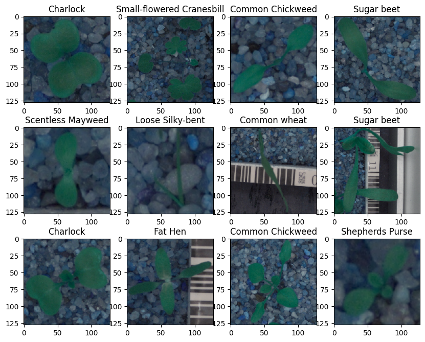

```python
num_classes=12                                                                  # Number of Classes
rows = 3                                                                        # Defining number of rows=3
cols = 4                                                                        # Defining number of columns=4
fig = plt.figure(figsize=(10, 8))                                               # Defining the figure size to 10x8
for i in range(cols):
    for j in range(rows):
        random_index = np.random.randint(0, len(labels))                        # Generating random indices from the data and plotting the images
        ax = fig.add_subplot(rows, cols, i * rows + j + 1)                      # Adding subplots with 3 rows and 4 columns
        ax.imshow(images_arr[random_index, :], cmap=plt.get_cmap('gray'))       # Plotting the image using cmap=gray
        ax.set_title(labels.iloc[random_index][0])                              # Setting the title
plt.show()
```

These are some of the images from the "images_arr" array. Let us look at more images of a single category before reporting our observations.

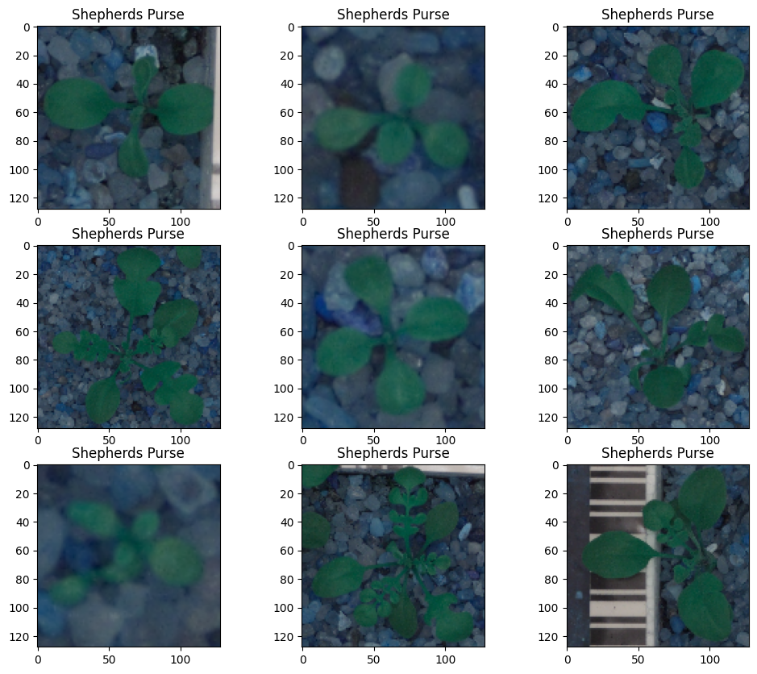

```python
# Setting the rows, columns and a random label to display images of.
rows = 3; cols = 3;
rand_lab = labels.value_counts().index[np.random.randint(0, num_classes)][0];

fig = plt.figure(figsize=(12, 10))
for i in range(cols):
    for j in range(rows):
      # Generating a random index from the size of the amount of this label.
      random_index = np.random.randint(0, len(labels[labels["Label"] == rand_lab ]))
      ax = fig.add_subplot(rows, cols, i * rows + j + 1)
      # Getting the index from the random index to locate the image
      loc_index = labels[labels["Label"] == rand_lab ].index[random_index]
      # Showing the image
      ax.imshow(images_arr[loc_index, :], cmap=plt.get_cmap('gray'))
      # Setting the title
      ax.set_title(rand_lab)
plt.show()
```

**Note:** *The following observations were done after observing various images the likes of which may not be displayed in this notebook.*

**Observations**:

- The majority of the images are displayed on top of what it seem to be rocks of colors around dark blue and gray. The plants itself are shown to be mostly green in color.
- Some images have what appears to be a ruler somewhere in the image with black and white markings. Even some plants are taken in front of this ruler instead of the rocks.
- Some images appear to be blurry of varying degree, making the plant hard to define to a human eye; while some other pictures have a clear focus of the plant.
- Some images present the plant in the center taking the majority of the file while some others take around 30% to 50% of the image.
- Some shapes of plants are thinner than others, while others are thicker than others; infering that its identification will be harder.

Now, we shall observe the distribution of each category.

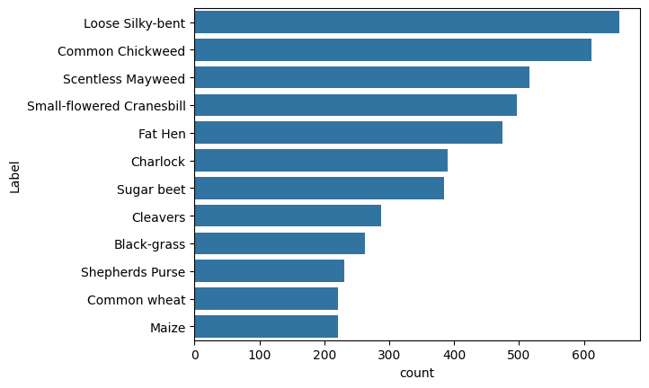

```python
# Plot distribution of each category
sns.countplot(data=labels, y="Label", order = labels["Label"].value_counts(ascending=False).index);
```

```python
# Observing the same in a table with normalized values (from 0 to 1)
labels["Label"].value_counts(normalize = True, ascending=False)
```

|  | Label |
| --- | --- |
| Loose Silky-bent | 0.137684 |
| Common Chickweed | 0.128632 |
| Scentless Mayweed | 0.108632 |
| Small-flowered Cranesbill | 0.104421 |
| Fat Hen | 0.100000 |
| Charlock | 0.082105 |
| Sugar beet | 0.081053 |
| Cleavers | 0.060421 |
| Black-grass | 0.055368 |
| Shepherds Purse | 0.048632 |
| Common wheat | 0.046526 |
| Maize | 0.046526 |

**dtype:** float64

**Observations:**

Therefore, the categories in question showcase an inbalance that we will keep in mind.

## Data Pre-Processing

Data Pre-Processing is one of the most important steps building a good model as very small details may have a big impact on training the model, like in its complexity, size or training time.

Let's look at the first image of the array as we process the data.

```
ndarray (128, 128, 3)
```

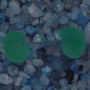

```
array([[[ 35,  52,  78],
        [ 36,  49,  76],
        [ 31,  45,  69],
        ...,
        [ 78,  95, 114],
        [ 76,  93, 110],
        [ 80,  95, 109]],

       [[ 33,  46,  68],
        [ 37,  50,  73],
        [ 48,  65,  83],
        ...,
        [ 81,  96, 113],
        [ 74,  89, 105],
        [ 83,  95, 109]],

       [[ 34,  50,  68],
        [ 35,  52,  72],
        [ 70,  85, 101],
        ...,
        [ 83,  97, 112],
        [ 79,  94, 108],
        [ 79,  94, 107]],

       ...,

       [[ 35,  50,  69],
        [ 42,  57,  73],
        [ 42,  57,  72],
        ...,
        [ 60,  76,  92],
        [ 67,  81,  97],
        [ 64,  77,  95]],

       [[ 36,  52,  67],
        [ 48,  63,  78],
        [ 41,  57,  73],
        ...,
        [ 44,  66,  83],
        [ 58,  76,  91],
        [ 57,  74,  90]],

       [[ 44,  58,  70],
        [ 43,  57,  73],
        [ 40,  55,  72],
        ...,
        [ 41,  70,  92],
        [ 55,  78,  97],
        [ 61,  79,  96]]], dtype=uint8)
```

```python
# Displaying the first image
images_arr[0]
```

### Convert the BGR images to RGB images.

Some libraries and models accept images in an BGR color space. We will, however, use RGB images; therefore we will have to transform our images to RGB.

```python
# We will make a copy to avoid directly manipulate the variable
images_rgb = images_arr.copy()

# Looping through all of the images
for i in range(len(images_rgb)):
  # Converts the color space using a cv2 method.
  images_rgb[i] = cv2.cvtColor(images_rgb[i], cv2.COLOR_BGR2RGB)
```

```
ndarray (128, 128, 3)
```

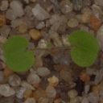

```
array([[[ 78,  52,  35],
        [ 76,  49,  36],
        [ 69,  45,  31],
        ...,
        [114,  95,  78],
        [110,  93,  76],
        [109,  95,  80]],

       [[ 68,  46,  33],
        [ 73,  50,  37],
        [ 83,  65,  48],
        ...,
        [113,  96,  81],
        [105,  89,  74],
        [109,  95,  83]],

       [[ 68,  50,  34],
        [ 72,  52,  35],
        [101,  85,  70],
        ...,
        [112,  97,  83],
        [108,  94,  79],
        [107,  94,  79]],

       ...,

       [[ 69,  50,  35],
        [ 73,  57,  42],
        [ 72,  57,  42],
        ...,
        [ 92,  76,  60],
        [ 97,  81,  67],
        [ 95,  77,  64]],

       [[ 67,  52,  36],
        [ 78,  63,  48],
        [ 73,  57,  41],
        ...,
        [ 83,  66,  44],
        [ 91,  76,  58],
        [ 90,  74,  57]],

       [[ 70,  58,  44],
        [ 73,  57,  43],
        [ 72,  55,  40],
        ...,
        [ 92,  70,  41],
        [ 97,  78,  55],
        [ 96,  79,  61]]], dtype=uint8)
```

```python
# Let's look at the same image again.
images_rgb[0]
```

Now, the features remain the same, however the colors have shifted a bit.

### Resize the images

As the size of the images is large, it may be computationally expensive to train on these larger images; therefore, it is preferable to reduce the image size from 128 to 64.

```python
# Resizing the images in a new array due to its new size.
prep_images = np.array([cv2.resize(image, (64, 64)) for image in images_rgb])

# Let's observe the first image again.
prep_images[0]
```

```
ndarray (64, 64, 3)
```

```
array([[[ 74,  49,  35],
        [ 83,  65,  49],
        [ 99,  82,  67],
        ...,
        [106,  91,  75],
        [112,  95,  79],
        [108,  93,  78]],

       [[ 72,  52,  34],
        [104,  88,  72],
        [114,  97,  80],
        ...,
        [102,  86,  72],
        [108,  93,  79],
        [108,  95,  80]],

       [[ 77,  56,  38],
        [100,  83,  67],
        [113,  95,  78],
        ...,
        [ 98,  83,  69],
        [105,  90,  76],
        [106,  92,  80]],

       ...,

       [[ 66,  43,  31],
        [ 67,  49,  33],
        [ 68,  50,  38],
        ...,
        [ 88,  67,  54],
        [ 96,  79,  62],
        [ 95,  76,  65]],

       [[ 71,  51,  37],
        [ 74,  58,  44],
        [ 73,  56,  46],
        ...,
        [ 81,  59,  45],
        [ 90,  73,  58],
        [ 97,  80,  67]],

       [[ 72,  58,  43],
        [ 73,  57,  41],
        [ 72,  56,  41],
        ...,
        [ 71,  45,  29],
        [ 85,  64,  39],
        [ 94,  77,  58]]], dtype=uint8)
```

As the resizing indicates, the dimensions are at a different size; to the human eye, the image looks smaller.

### Data Preparation for Modeling

- Before you proceed to build a model, one needs to split the data into train, test, and validation to be able to evaluate the model that it's build on the train data
- One will have to encode categorical features and scale the pixel values.

#### **Split the dataset**

Here we will split the data into three sets: Training, Validation and Test sets. We will employ the Training and Validation set to build and improve the model respectively. To avoid data leakage, we will avoid employing the test set until the model is ready to be deployed.

```python
# Splitting the data into X and y train and a temp set, with the latter having 40% of the data.
X_train, X_temp, y_train, y_temp = train_test_split(prep_images, labels, test_size=0.4, random_state=0, stratify=labels)

# then, we split the temp into validation and test, with the latter having 40% of the data from temp.
X_val, X_test, y_val, y_test = train_test_split(X_temp, y_temp, test_size=0.4, random_state=0, stratify=y_temp)

# Observing the number of observations in each set.
print(X_train.shape[0], X_val.shape[0], X_test.shape[0])
```

```
2850 1140 760
```

#### Encode the target labels

Recall that our labels are stored in a dataframe with only its alphanumerical value. In order to build the model, we will have to encode our labels into a numerical format.

```python
# Storing the LabelBinarizer function in lb variable
lb = LabelBinarizer()
# Applying fit_transform on train target variable
y_train = lb.fit_transform(y_train)
# Applying only transform on test and validation target variable
y_val = lb.transform(y_val)
y_test = lb.transform(y_test)
```

We are going to keep a dictionary with each index and label, so that we can understand the values outside of the model.

```python
# Creating the dictionary with the LabelBinarizer's attribute "classes_"
# Which keeps the labels with each index
index_to_label = {index: label for index, label in enumerate(lb.classes_)}

# Showing the dictionary
index_to_label
```

```
{0: 'Black-grass',
 1: 'Charlock',
 2: 'Cleavers',
 3: 'Common Chickweed',
 4: 'Common wheat',
 5: 'Fat Hen',
 6: 'Loose Silky-bent',
 7: 'Maize',
 8: 'Scentless Mayweed',
 9: 'Shepherds Purse',
 10: 'Small-flowered Cranesbill',
 11: 'Sugar beet'}
```

#### Setting Class Weights

```python
# Getting the labels
y_train_labels = np.argmax(y_train, axis=1)

# Compute class weights
class_weights = class_weight.compute_class_weight('balanced', classes=np.unique(y_train_labels), y=y_train_labels)

# Creating a dictionnary to establish the weights
class_weight_dict = {i: class_weights[i] for i in range(len(class_weights))}

#print calculated class weights
class_weight_dict
```

```
{0: 1.5031645569620253,
 1: 1.014957264957265,
 2: 1.380813953488372,
 3: 0.6471389645776566,
 4: 1.7857142857142858,
 5: 0.8333333333333334,
 6: 0.6058673469387755,
 7: 1.7992424242424243,
 8: 0.7661290322580645,
 9: 1.70863309352518,
 10: 0.7996632996632996,
 11: 1.0281385281385282}
```

#### Data Normalization

Finally, we will normalize the values of the images in order to regularize the data. This is a simple step, yet a crucial one in some cases.

```python
# Dividing the values of the images by is maximum value (255)
# Define it as 255.0 to establish the result as a float
X_train = X_train / 255.0
X_val   = X_val   / 255.0
X_test  = X_test  / 255.0
```

## Model Building

In this section, we will build a single CNN model with mostly default parameters and no techniques as a form of control. Further along we will imporve the model with various techniques.

The main metric of interest during our evaluation is "accuracy", as we are mostly interested in getting the model to correctly identify all the images equally. Other metrics, such as loss, are used to compare similar models and their performance.

### Utility Functions

First, let's **set the seed for random number generators in NumPy, Python, and TensorFlow** to be able to reproduce the same results every time we run the code.

```python
#Fixing the seed for random number generators
np.random.seed(0)
random.seed(0)
tf.random.set_seed(0)
```

Another command we will see recurrently clears the model's history from memory so no other model affect the one we will build.

```python
# Clearing backend
backend.clear_session()
```

When the model finishes its training procedure, we will display its results on a graph comparing training and validation performance. Let's define that function.

```python
def plot_history(model_history):
  # Plotting the accuracy of the training set
  plt.plot(model_history.history['accuracy'])
  # Plotting the accuracy of the validation set on the same graph
  plt.plot(model_history.history['val_accuracy'])
  # Setting the title
  plt.title('Model Accuracy')
  # Setting the label of the y axis
  plt.ylabel('Accuracy')
  # setting the label of the x axis
  plt.xlabel('Epoch')
  # Establishing the legend of the graph
  plt.legend(['Train', 'Validation'], loc='upper left')
  # showing the plot
  plt.show()
```

Another way of displaying the performance of the model, a confusion matrix. We shall define its function here.

```python
# Function to create a confusion matrix
def plot_confusion_matrix(pred, target):
  # We use the method by tensor flow to make te matrix
  confusion_matrix = tf.math.confusion_matrix(pred, target)
  # We plot it using seaborns' heatmap
  f, ax = plt.subplots(figsize=(10,8))
  sns.heatmap(
      confusion_matrix,
      annot=True,
      linewidths=0.5,
      fmt="d",
      square=True,
      ax=ax
  )
  # Showing the plot
  plt.show()
```

### Building The Model

A CNN Model contains 2 main parts:

1. **The Feature Extraction layers** which are comprised of convolutional and pooling layers.
2. **The Fully Connected classification layers for prediction.**

```python
# Intializing a sequential model
model_1 = Sequential()

# Feature Extractions

# Adding first conv layer with 64 filters and kernel size 3x3 , padding 'same' provides the output size same as the input size
# Input_shape denotes input image dimension of our images
model_1.add(Conv2D(64, (3, 3), activation='relu', padding="same", input_shape=(64, 64, 3)))

# Adding max pooling to reduce the size of output of first conv layer
model_1.add(MaxPooling2D((2, 2), padding = 'same'))

# Adding two more layers of each
model_1.add(Conv2D(32, (3, 3), activation='relu', padding="same"))
model_1.add(MaxPooling2D((2, 2), padding = 'same'))

model_1.add(Conv2D(32, (3, 3), activation='relu', padding="same"))
model_1.add(MaxPooling2D((2, 2), padding = 'same'))

# flattening the output of the conv layer after max pooling to make it ready for creating dense connections
model_1.add(Flatten())


# Prediction Layers
# Adding a fully connected dense layer with 64 neurons
model_1.add(Dense(64, activation='relu'))

# Adding the output layer with 12 neurons and activation functions as softmax since this is a multi-class classification problem
model_1.add(Dense(12, activation='softmax'))

# Using SGD Optimizer
opt = SGD(learning_rate=0.01, momentum=0.9)

# Compile model
model_1.compile(optimizer=opt, loss='categorical_crossentropy', metrics=['accuracy'])

# Setting the name of the model for legibility
model_1._name = "First_Model"

# Generating the summary of the model
model_1.summary()
```

```
Model: "First_Model"
_________________________________________________________________
 Layer (type)                Output Shape              Param #
=================================================================
 conv2d (Conv2D)             (None, 64, 64, 64)        1792

 max_pooling2d (MaxPooling2  (None, 32, 32, 64)        0
 D)

 conv2d_1 (Conv2D)           (None, 32, 32, 32)        18464

 max_pooling2d_1 (MaxPoolin  (None, 16, 16, 32)        0
 g2D)

 conv2d_2 (Conv2D)           (None, 16, 16, 32)        9248

 max_pooling2d_2 (MaxPoolin  (None, 8, 8, 32)          0
 g2D)

 flatten (Flatten)           (None, 2048)              0

 dense (Dense)               (None, 64)                131136

 dense_1 (Dense)             (None, 12)                780

=================================================================
Total params: 161420 (630.55 KB)
Trainable params: 161420 (630.55 KB)
Non-trainable params: 0 (0.00 Byte)
_________________________________________________________________
```

We have now built the CNN model. The summary above informs us about the types of layers in the model in order, as well as the number of parameters, trainable or not.  
After the model has been built succesfully, we will proceed with training the model with our train data, otherwise known as fitting the model; as well as our validation set to improve its performance in training. This will be stored in a variable called history so we can observe its performance during the training period.  
Additional paramters that will be introduced:

- `batch_size`: Number of samples per gradient update. We will set this to 64.
- `epochs`: The number of epochs, or iterations over the traininng set, to train the model with. We will set this to 10.
- `class_weight`: The class weight (dictionary) created due to the inbalance of classes.

```python
# Fitting the model with our training and validation dataset
history_1 = model_1.fit(
    # Train set
    X_train, y_train,
    # Validation set
    validation_data=(X_val, y_val),
    # Size of the batches
    batch_size=64,
    # Number of epochs
    epochs=10,
    # class weights
    class_weight=class_weight_dict,
)
```

#### Model Evaluation

Let's observe how well the model performed in a graph.

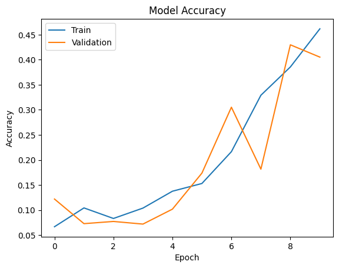

```python
# calling the utility function to plot the history
plot_history(history_1)
```

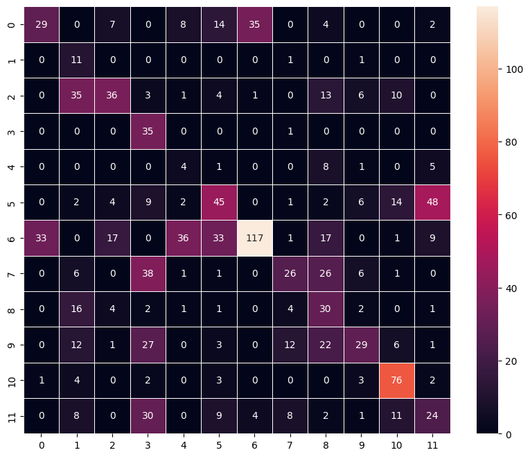

```python
# Plotting the confusion matrix
predicted = np.argmax(model_1.predict(X_val), axis=1)
target = np.argmax(y_val, axis=1)
plot_confusion_matrix(predicted, target)
```

**Observations:**

As we can see, this simple model leaves better results to be desired, therefore we will improve its performance.

## Model Performance Improvement

During this section, we will begin introducing different techniques to improve the model's performance.

**Note:** *Some of the model's parameters will remain unchanged. We will only mention new parameters or modified ones to avoid redundacy.*

#### Callbacks

During our first model there were moments where our model decreased performance. For that purpose we will introduce some callbacks with the intention of modifying the procedure in accordance of the callback.

**Reducing the Learning Rate:**

First we shall start by using `ReduceLRonPlateau()` function, that will be used to decrease the learning rate by some factor, if the loss is not decreasing for some time. This may start decreasing the loss at a smaller learning rate. There is a possibility that the loss may still not decrease. This may lead to executing the learning rate reduction again in an attempt to achieve a lower loss.

**Early stopping** is a technique similar to cross-validation where a part of training data is kept as the validation data. When the performance of the validation data starts worsening, the model will immediately stop the training.

- **Monitor**: Quantity to be monitored.
- **Mode**: One of {"auto", "min", "max"}. In min mode, training will stop when the quantity monitored has stopped decreasing; in "max" mode it will stop when the quantity monitored has stopped increasing; in "auto" mode, the direction is automatically inferred from the name of the monitored quantity.
- **Patience**: Number of epochs with no improvement after which training will be stopped.

**ModelCheckpoint** callback is used in conjunction with training using model. fit() to save a model or weights (in a checkpoint file) at some interval, so the model or weights can be loaded later to continue the training from the state saved.

```python
# Before building the model, we will clean the memory space
backend.clear_session()
```

We shall build the same model to compare performances.

```python
# Intializing a sequential model
model_2 = Sequential()

# Feature Extractions

# Adding first conv layer with 64 filters and kernel size 3x3 , padding 'same' provides the output size same as the input size
# Input_shape denotes input image dimension of our images
model_2.add(Conv2D(64, (3, 3), activation='relu', padding="same", input_shape=(64, 64, 3)))

# Adding max pooling to reduce the size of output of first conv layer
model_2.add(MaxPooling2D((2, 2), padding = 'same'))

# Adding two more layers of each
model_2.add(Conv2D(32, (3, 3), activation='relu', padding="same"))
model_2.add(MaxPooling2D((2, 2), padding = 'same'))

model_2.add(Conv2D(32, (3, 3), activation='relu', padding="same"))
model_2.add(MaxPooling2D((2, 2), padding = 'same'))

# flattening the output of the conv layer after max pooling to make it ready for creating dense connections
model_2.add(Flatten())


# Prediction Layers
# Adding a fully connected dense layer with 64 neurons
model_2.add(Dense(64, activation='relu'))

# Adding the output layer with 12 neurons and activation functions as softmax since this is a multi-class classification problem
model_2.add(Dense(12, activation='softmax'))

# Using SGD Optimizer
opt = SGD(learning_rate=0.01, momentum=0.9)

# Compile model
model_2.compile(optimizer=opt, loss='categorical_crossentropy', metrics=['accuracy'])

# Setting the model name
model_2._name = "Callbacks"

# Generating the summary of the model
model_2.summary()
```

```
Model: "Callbacks"
_________________________________________________________________
 Layer (type)                Output Shape              Param #
=================================================================
 conv2d (Conv2D)             (None, 64, 64, 64)        1792

 max_pooling2d (MaxPooling2  (None, 32, 32, 64)        0
 D)

 conv2d_1 (Conv2D)           (None, 32, 32, 32)        18464

 max_pooling2d_1 (MaxPoolin  (None, 16, 16, 32)        0
 g2D)

 conv2d_2 (Conv2D)           (None, 16, 16, 32)        9248

 max_pooling2d_2 (MaxPoolin  (None, 8, 8, 32)          0
 g2D)

 flatten (Flatten)           (None, 2048)              0

 dense (Dense)               (None, 64)                131136

 dense_1 (Dense)             (None, 12)                780

=================================================================
Total params: 161420 (630.55 KB)
Trainable params: 161420 (630.55 KB)
Non-trainable params: 0 (0.00 Byte)
_________________________________________________________________
```

We will increase the number of epoch to 20

```python
# Here, we will introduce our callbacks
r_lr = ReduceLROnPlateau(monitor='val_loss', factor=0.2, patience=4, min_lr=0.001)
es   = EarlyStopping(monitor='val_loss', mode='min', verbose=1, patience=5)
mc   = ModelCheckpoint('best_model.h2', monitor='val_accuracy', mode='max', verbose=1, save_best_only=True)

# Fitting the model with 20 epochs and our callbacks
history_2=model_2.fit(
    X_train, y_train,
    validation_data=(X_val, y_val),
    epochs=20,
    batch_size=64,
    class_weight=class_weight_dict,
    callbacks=[es, mc, r_lr]
)
```

```
Epoch 1: val_accuracy improved from -inf to 0.12105, saving model to best_model.h2
Epoch 2: val_accuracy did not improve from 0.12105
Epoch 3: val_accuracy did not improve from 0.12105
Epoch 4: val_accuracy did not improve from 0.12105
Epoch 5: val_accuracy improved from 0.12105 to 0.13860, saving model to best_model.h2
Epoch 6: val_accuracy improved from 0.13860 to 0.19737, saving model to best_model.h2
Epoch 7: val_accuracy improved from 0.19737 to 0.37368, saving model to best_model.h2
Epoch 8: val_accuracy did not improve from 0.37368
Epoch 9: val_accuracy improved from 0.37368 to 0.46228, saving model to best_model.h2
Epoch 10: val_accuracy did not improve from 0.46228
Epoch 11: val_accuracy improved from 0.46228 to 0.54912, saving model to best_model.h2
Epoch 12: val_accuracy did not improve from 0.54912
Epoch 13: val_accuracy did not improve from 0.54912
Epoch 14: val_accuracy improved from 0.54912 to 0.60439, saving model to best_model.h2
Epoch 15: val_accuracy improved from 0.60439 to 0.62368, saving model to best_model.h2
Epoch 16: val_accuracy did not improve from 0.62368
Epoch 17: val_accuracy improved from 0.62368 to 0.66491, saving model to best_model.h2
Epoch 18: val_accuracy improved from 0.66491 to 0.67544, saving model to best_model.h2
Epoch 19: val_accuracy did not improve from 0.67544
Epoch 20: val_accuracy did not improve from 0.67544
```

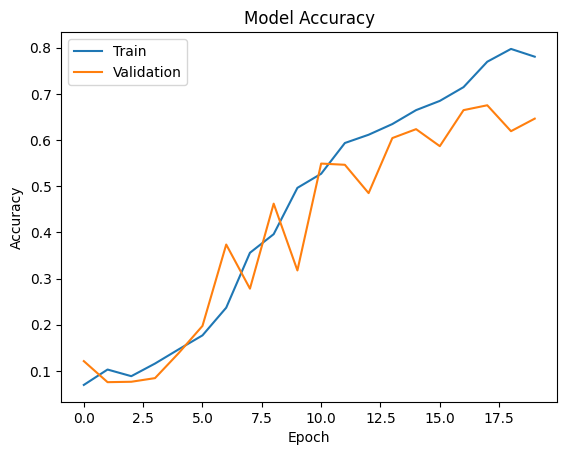

```python
# Let's observe the plot history
plot_history(history_2)
```

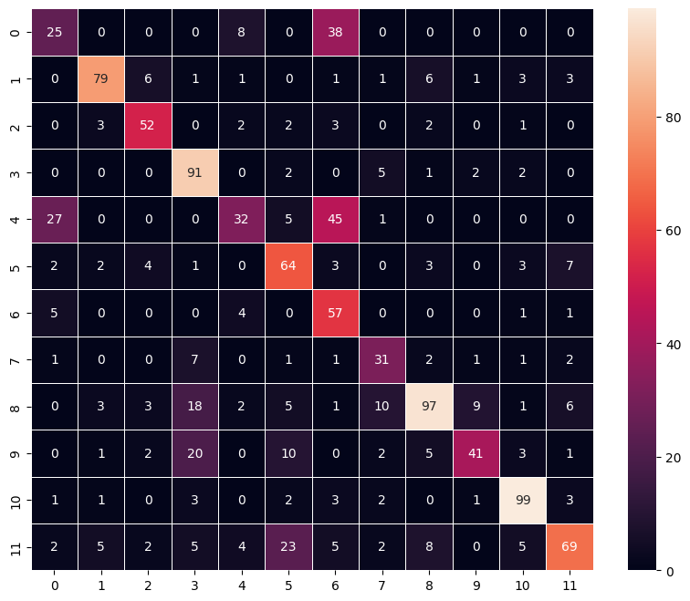

```python
# Plotting the confusion matrix
predicted = np.argmax(model_2.predict(X_val), axis=1)
target = np.argmax(y_val, axis=1)
plot_confusion_matrix(predicted, target)
```

**Observations:**

Let's rebuild the model again, but with new features this time in order to observe different results

### Dropout layers & ADAM

In this new model, we will introduce Dropout layers to the feature extractions and to the prediction layers, as well as changing the optimizer to, hopefully, improve the loss' performance.

```python
# Before building the model, we will clean the memory space
backend.clear_session()
```

```python
# Intializing a sequential model
model_3 = Sequential()

# Feature Extractions

# Adding first conv layer with 64 filters and kernel size 3x3 , padding 'same' provides the output size same as the input size
# Input_shape denotes input image dimension of our images
model_3.add(Conv2D(64, (3, 3), activation='relu', padding="same", input_shape=(64, 64, 3)))

# Adding max pooling to reduce the size of output of first conv layer
model_3.add(MaxPooling2D((2, 2), padding = 'same'))

# Adding a dropout of 20%
model_3.add(Dropout(0.20))

# Adding two more layers of each
model_3.add(Conv2D(32, (3, 3), activation='relu', padding="same"))
model_3.add(MaxPooling2D((2, 2), padding = 'same'))

# Adding a dropout of 20%
model_3.add(Dropout(0.20))

model_3.add(Conv2D(32, (3, 3), activation='relu', padding="same"))
model_3.add(MaxPooling2D((2, 2), padding = 'same'))

# flattening the output of the conv layer after max pooling to make it ready for creating dense connections
model_3.add(Flatten())


# Prediction Layers
# Adding a fully connected dense layer with 64 neurons
model_3.add(Dense(64, activation='relu'))

# Adding a dropout layer of 20%
model_3.add(Dropout(0.20))

# Adding the output layer with 12 neurons and activation functions as softmax since this is a multi-class classification problem
model_3.add(Dense(12, activation='softmax'))

# Using Adam Optimizer
opt = Adam(learning_rate=0.01)

# Compile model
model_3.compile(optimizer=opt, loss='categorical_crossentropy', metrics=['accuracy'])

# Setting the model name
model_3._name = "Dropout_Adam"

# Generating the summary of the model
model_3.summary()
```

```
Model: "Dropout_Adam"
_________________________________________________________________
 Layer (type)                Output Shape              Param #
=================================================================
 conv2d (Conv2D)             (None, 64, 64, 64)        1792

 max_pooling2d (MaxPooling2  (None, 32, 32, 64)        0
 D)

 dropout (Dropout)           (None, 32, 32, 64)        0

 conv2d_1 (Conv2D)           (None, 32, 32, 32)        18464

 max_pooling2d_1 (MaxPoolin  (None, 16, 16, 32)        0
 g2D)

 dropout_1 (Dropout)         (None, 16, 16, 32)        0

 conv2d_2 (Conv2D)           (None, 16, 16, 32)        9248

 max_pooling2d_2 (MaxPoolin  (None, 8, 8, 32)          0
 g2D)

 flatten (Flatten)           (None, 2048)              0

 dense (Dense)               (None, 64)                131136

 dropout_2 (Dropout)         (None, 64)                0

 dense_1 (Dense)             (None, 12)                780

=================================================================
Total params: 161420 (630.55 KB)
Trainable params: 161420 (630.55 KB)
Non-trainable params: 0 (0.00 Byte)
_________________________________________________________________
```

```python
# Here, we will reintroduce our callbacks
r_lr = ReduceLROnPlateau(monitor='val_loss', factor=0.2, patience=3, min_lr=0.001)
es   = EarlyStopping(monitor='val_loss', mode='min', verbose=1, patience=5)
mc   = ModelCheckpoint('best_model.h3', monitor='val_accuracy', mode='max', verbose=1, save_best_only=True)

# Fitting the model with 20 epochs and our callbacks
history_3=model_3.fit(
    X_train, y_train,
    validation_data=(X_val, y_val),
    epochs=20,
    batch_size=64,
    class_weight=class_weight_dict,
    callbacks=[es, mc, r_lr]
)
```

```
Epoch 1: val_accuracy improved from -inf to 0.13772, saving model to best_model.h3
Epoch 2: val_accuracy did not improve from 0.13772
Epoch 3: val_accuracy did not improve from 0.13772
Epoch 4: val_accuracy did not improve from 0.13772
Epoch 5: val_accuracy did not improve from 0.13772
Epoch 6: val_accuracy did not improve from 0.13772
Epoch 6: early stopping
```

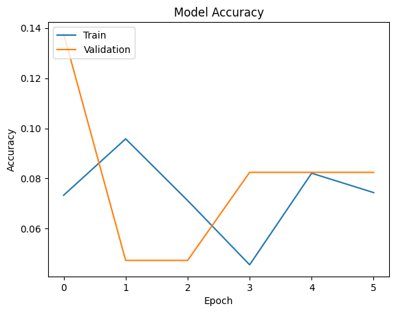

```python
# Lets observe the history
plot_history(history_3)
```

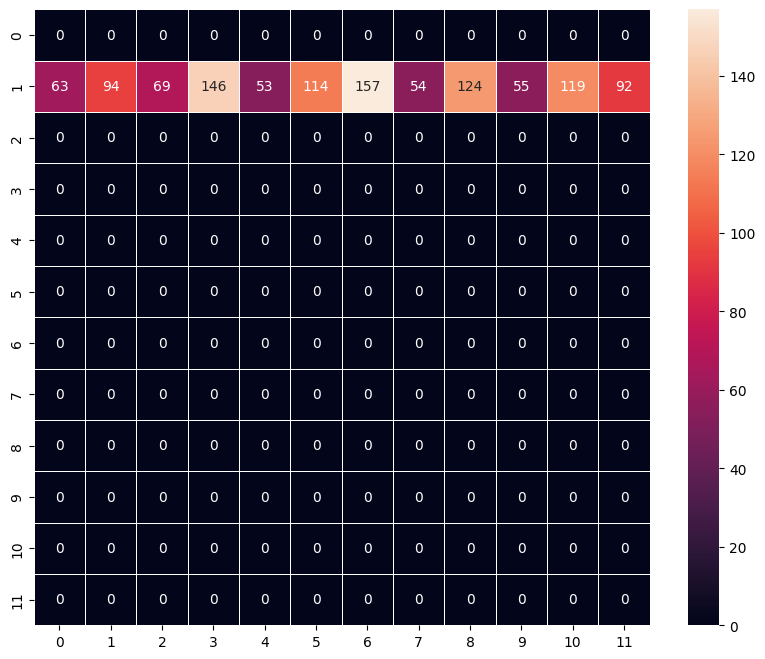

```python
# Plotting the confusion matrix
predicted = np.argmax(model_3.predict(X_val), axis=1)
target = np.argmax(y_val, axis=1)
plot_confusion_matrix(predicted, target)
```

**Observations:**

- The results are still subpar, yet it does not overfit.

### **Data Augmentation**

Data augmentation is one of our improvement techniques that helps us improve the size of our training set as the original size was very low. With this technique, we will bring alterated images of our original source of images to introduce variability to our model in order to boost performance.  
It is important to remember, **data augmentation should not be used in the validation/test data set**.

```python
# Creating the instance of the generator with
# our desired augmentations
train_datagen = ImageDataGenerator(
    rotation_range=40,
    width_shift_range=0.2,
    height_shift_range=0.2,
    shear_range=0.2,
    zoom_range=0.2,
    horizontal_flip=True,
    vertical_flip=True,
)

# We fit the instance to our images.
train_datagen.fit(X_train)

# After it has been fitted, we will "flow" the information to
# our new variable.
augmented_data = train_datagen.flow(X_train, y_train, batch_size=64)
```

#### Building the model

Now that we have a new set of training data (`augmented_data`, which contains the images and labels), we can build a model to fit. Additionally, we will introduce a new layer, `BatchNormalization`, to reduce overfitting and normalize the data.

```python
# Before building the model, we will clean the memory space
backend.clear_session()
```

```python
# Intializing a sequential model
model_4 = Sequential()

# Feature Extractions

# Adding first conv layer with 64 filters and kernel size 3x3 , padding 'same' provides the output size same as the input size
# Input_shape denotes input image dimension of our images
model_4.add(Conv2D(64, (3, 3), activation='relu', padding="same", input_shape=(64, 64, 3)))

# Adding max pooling to reduce the size of output of first conv layer
model_4.add(MaxPooling2D((2, 2), padding = 'same'))

# Adding batch normalization
model_4.add(BatchNormalization())

# Adding two more layers of each
model_4.add(Conv2D(32, (3, 3), activation='relu', padding="same"))
model_4.add(MaxPooling2D((2, 2), padding = 'same'))

# Adding batch normalization
model_4.add(BatchNormalization())

# Adding a dropout of 20%
model_4.add(Dropout(0.20))

model_4.add(Conv2D(32, (3, 3), activation='relu', padding="same"))
model_4.add(MaxPooling2D((2, 2), padding = 'same'))

# flattening the output of the conv layer after max pooling to make it ready for creating dense connections
model_4.add(Flatten())


# Prediction Layers
# Adding a fully connected dense layer with 64 neurons
model_4.add(Dense(64, activation='relu'))

# Adding a dropout layer of 20%
model_4.add(Dropout(0.20))

# Adding the output layer with 12 neurons and activation functions as softmax since this is a multi-class classification problem
model_4.add(Dense(12, activation='softmax'))

# Using Adam Optimizer
opt = Adam(learning_rate=0.01)

# Compile model
model_4.compile(optimizer=opt, loss='categorical_crossentropy', metrics=['accuracy'])

# Setting the model name
model_4._name = "Augmented"

# Generating the summary of the model
model_4.summary()
```

```
Model: "Augmented"
_________________________________________________________________
 Layer (type)                Output Shape              Param #
=================================================================
 conv2d (Conv2D)             (None, 64, 64, 64)        1792

 max_pooling2d (MaxPooling2  (None, 32, 32, 64)        0
 D)

 batch_normalization (Batch  (None, 32, 32, 64)        256
 Normalization)

 conv2d_1 (Conv2D)           (None, 32, 32, 32)        18464

 max_pooling2d_1 (MaxPoolin  (None, 16, 16, 32)        0
 g2D)

 batch_normalization_1 (Bat  (None, 16, 16, 32)        128
 chNormalization)

 dropout (Dropout)           (None, 16, 16, 32)        0

 conv2d_2 (Conv2D)           (None, 16, 16, 32)        9248

 max_pooling2d_2 (MaxPoolin  (None, 8, 8, 32)          0
 g2D)

 flatten (Flatten)           (None, 2048)              0

 dense (Dense)               (None, 64)                131136

 dropout_1 (Dropout)         (None, 64)                0

 dense_1 (Dense)             (None, 12)                780

=================================================================
Total params: 161804 (632.05 KB)
Trainable params: 161612 (631.30 KB)
Non-trainable params: 192 (768.00 Byte)
_________________________________________________________________
```

```python
# Here, we will reintroduce our callbacks
r_lr = ReduceLROnPlateau(monitor='val_loss', factor=0.2, patience=3, min_lr=0.0001)
es   = EarlyStopping(monitor='val_loss', mode='min', verbose=1, patience=5)
mc   = ModelCheckpoint('best_model.h4', monitor='val_accuracy', mode='max', verbose=1, save_best_only=True)

# Fitting the model with 20 epochs and our callbacks
history_4 = model_4.fit(
    # Using our augmented set
    augmented_data,
    validation_data=(X_val, y_val),
    epochs=20,
    batch_size=64,
    class_weight=class_weight_dict,
    callbacks=[es, mc, r_lr]
)
```

```
Epoch 1: val_accuracy improved from -inf to 0.05526, saving model to best_model.h4
Epoch 2: val_accuracy did not improve from 0.05526
Epoch 3: val_accuracy did not improve from 0.05526
Epoch 4: val_accuracy did not improve from 0.05526
Epoch 5: val_accuracy did not improve from 0.05526
Epoch 6: val_accuracy did not improve from 0.05526
Epoch 6: early stopping
```

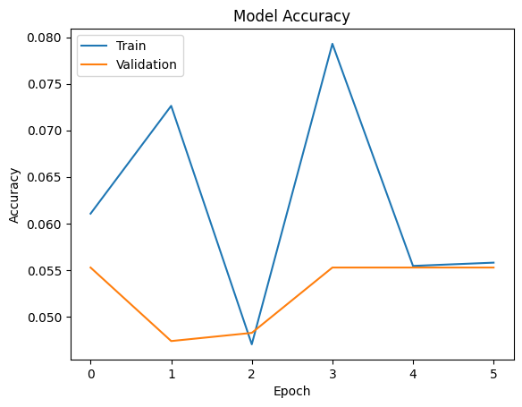

```python
# Let's observe performance
plot_history(history_4)
```

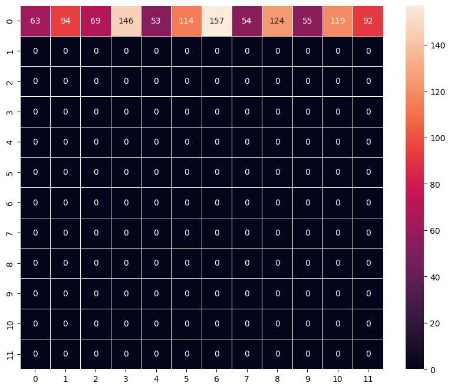

```python
# Plotting the confusion matrix
predicted = np.argmax(model_4.predict(X_val), axis=1)
target = np.argmax(y_val, axis=1)
plot_confusion_matrix(predicted, target)
```

**Observations:**

- The train and validation dataset are not so far apart, this shows that the model is not overfitting.
- The score is still too low.

### Final Model

We are going to build this last model by using everything we've tried so far in an attempt to improve performance.  
It is important to note that there are still more techniques that can be applied to the current problem at hand that could improve performance like "Transfer Learning" and "Oversampling", among others. We are not going to implement these into this notebook for the sake of complexity of the same.

```python
# Clreaing the history
backend.clear_session()
```

```python
# Intializing a sequential model
model_5 = Sequential()

# Feature Extractions

# Adding first conv layer with 64 filters and kernel size 3x3 , padding 'same' provides the output size same as the input size
# Input_shape denotes input image dimension of our images
model_5.add(Conv2D(64, (3, 3), activation='relu', padding="same", input_shape=(64, 64, 3)))

# Adding max pooling to reduce the size of output of first conv layer
model_5.add(MaxPooling2D((2, 2), padding = 'same'))

# Adding batch normalization
model_5.add(BatchNormalization())

# Another conv and pool layer
model_5.add(Conv2D(32, (3, 3), activation='relu', padding="same"))
model_5.add(MaxPooling2D((2, 2), padding = 'same'))
model_5.add(BatchNormalization())

# Adding a dropout of 20%
model_5.add(Dropout(0.20))

# Another conv, pool, batch and dropout layer
model_5.add(Conv2D(32, (3, 3), activation='leaky_relu', padding="same"))
model_5.add(MaxPooling2D((2, 2), padding = 'same'))
model_5.add(BatchNormalization())
model_5.add(Dropout(0.25))

model_5.add(Conv2D(64, (3, 3), activation='tanh', padding="same"))
model_5.add(MaxPooling2D((2, 2), padding = 'same'))
model_5.add(BatchNormalization())

# flattening the output of the conv layer after max pooling to make it ready for creating dense connections
model_5.add(Flatten())


# Prediction Layers
# Adding a fully connected dense layer with 128 neurons
model_5.add(Dense(128, activation='relu'))

# Adding a layer of BatchNormalization
model_5.add(BatchNormalization())

# Adding another dense layer
model_5.add(Dense(64, activation='relu'))

# Adding a layer of BatchNormalization
model_5.add(BatchNormalization())

# Adding a dropout layer of 20%
model_5.add(Dropout(0.20))

# Adding another dense layer
model_5.add(Dense(100, activation="leaky_relu"))

# Adding a layer of BatchNormalization
model_5.add(BatchNormalization())

# Adding the output layer with 12 neurons and activation functions as softmax since this is a multi-class classification problem
model_5.add(Dense(12, activation='softmax'))

# Using Adam Optimizer
opt = Adam(learning_rate=0.001)

# Compile model
model_5.compile(optimizer=opt, loss='categorical_crossentropy', metrics=['accuracy'])

# Setting the name of the model
model_5._name = "Last_Model"

# Generating the summary of the model
model_5.summary()
```

```
Model: "Last_Model"
_________________________________________________________________
 Layer (type)                Output Shape              Param #
=================================================================
 conv2d (Conv2D)             (None, 64, 64, 64)        1792

 max_pooling2d (MaxPooling2  (None, 32, 32, 64)        0
 D)

 batch_normalization (Batch  (None, 32, 32, 64)        256
 Normalization)

 conv2d_1 (Conv2D)           (None, 32, 32, 32)        18464

 max_pooling2d_1 (MaxPoolin  (None, 16, 16, 32)        0
 g2D)

 batch_normalization_1 (Bat  (None, 16, 16, 32)        128
 chNormalization)

 dropout (Dropout)           (None, 16, 16, 32)        0

 conv2d_2 (Conv2D)           (None, 16, 16, 32)        9248

 max_pooling2d_2 (MaxPoolin  (None, 8, 8, 32)          0
 g2D)

 batch_normalization_2 (Bat  (None, 8, 8, 32)          128
 chNormalization)

 dropout_1 (Dropout)         (None, 8, 8, 32)          0

 conv2d_3 (Conv2D)           (None, 8, 8, 64)          18496

 max_pooling2d_3 (MaxPoolin  (None, 4, 4, 64)          0
 g2D)

 batch_normalization_3 (Bat  (None, 4, 4, 64)          256
 chNormalization)

```

[output cut: 11 more lines]

```

 dropout_2 (Dropout)         (None, 64)                0

 dense_2 (Dense)             (None, 100)               6500

 batch_normalization_6 (Bat  (None, 100)               400
 chNormalization)

 dense_3 (Dense)             (None, 12)                1212

=================================================================
Total params: 197104 (769.94 KB)
Trainable params: 196136 (766.16 KB)
Non-trainable params: 968 (3.78 KB)
_________________________________________________________________
```

```python
# Here, we will reintroduce our callbacks
r_lr = ReduceLROnPlateau(monitor='val_loss', factor=0.5, patience=3, min_lr=0.0001)
es   = EarlyStopping(monitor='val_loss', mode='min', verbose=1, patience=5)
mc   = ModelCheckpoint('best_model.h5', monitor='val_accuracy', mode='max', verbose=1, save_best_only=True)

# Fitting the model with 20 epochs and our callbacks
history_5= model_5.fit(
    # Using our augmented set
    augmented_data,
    validation_data=(X_val, y_val),
    epochs=20,
    batch_size=80,
    class_weight=class_weight_dict,
    callbacks=[es, mc, r_lr]
)
```

```
Epoch 1: val_accuracy improved from -inf to 0.13772, saving model to best_model.h5
Epoch 2: val_accuracy did not improve from 0.13772
Epoch 3: val_accuracy did not improve from 0.13772
Epoch 4: val_accuracy did not improve from 0.13772
Epoch 5: val_accuracy did not improve from 0.13772
Epoch 6: val_accuracy did not improve from 0.13772
Epoch 6: early stopping
```

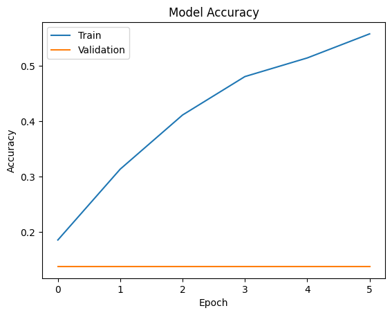

```python
# Let's observe its performance
plot_history(history_5)
```

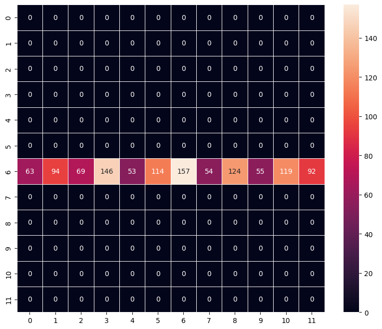

```python
# Plotting the confusion matrix
predicted = np.argmax(model_5.predict(X_val), axis=1)
target = np.argmax(y_val, axis=1)
plot_confusion_matrix(predicted, target)
```

**Observations:**

- Performance is still subpar, difference between validation and train dataset starting to increse from the previous one

## Final Model Selection and Evaluation

After creating different models, let us compare the performance on each of them using the validation set.

```python
# Creating a DataFrame to hold the performance of the models
evaluation_df = pd.DataFrame(columns=["Name", "Train_Loss", "Train_Acc", "Val_Loss", "Val_Acc"])
models = [model_1, model_2, model_3, model_4, model_5]

# Iterating throughout the models
for model in models:
  # Evaluating Performance on Train data
  train_perf = model.evaluate(X_train, y_train)
  # Evaluating Performance on Validation data
  val_perf = model.evaluate(X_val, y_val)

  # Appending the information
  evaluation_df = evaluation_df.append(
      {
          "Name": model._name,
          "Train_Loss": train_perf[0],
          "Train_Acc": train_perf[1],
          "Val_Loss": val_perf[0],
          "Val_Acc": val_perf[1]
      },
      ignore_index=True
  )

evaluation_df
```

|  | Name | Train_Loss | Train_Acc | Val_Loss | Val_Acc |
| --- | --- | --- | --- | --- | --- |
| 0 | First_Model | 1.508616 | 0.455789 | 1.612285 | 0.405263 |
| 1 | Callbacks | 0.423064 | 0.850877 | 1.037382 | 0.687719 |
| 2 | Dropout_Adam | 2.485555 | 0.082105 | 2.485527 | 0.082456 |
| 3 | Augmented | 2.485417 | 0.055088 | 2.484979 | 0.055263 |
| 4 | Last_Model | 9.256776 | 0.137544 | 9.246721 | 0.137719 |

**Observations:**

- Due to the lack of time at the elaboration of this notebook, only 5 models were able to be created. The results of them were very oscilating, with some models barely reaching a consistent 20% accuracy.
- Ideally, for the final model to be selected, we would choose the one that had a high accuracy and presented little to no overfitting. Unfortunately, from the models built, the performance is quite underwhelming.
- As one has to be chosen to be the final model, we must consider our options.
  - The first model has the second highest accuracy scores of all the models. It also, doesn't present any overfitting.
  - Another contender is the Callbacks model, as it has the highest accuracy of ~70% in the validation set, however it does overfit.
- After profound deliveration, we will chose the second model ("callbacks") to be the final model. The deciding factor in this decision was the validation accuracy score, mainly seen in the confusion matrix. Although it overfits, this models ends up being the best from the selection.

**Note:** *The selection is subjective to the judgement of the data scientist. Further comments about the models can be found in the conclusions.*

### Visualizing the prediction

Let's observe the prediction power in practice.

```python
# Generating a prediction from the test set
y_pred_test = model_2.predict(X_test)

# getting the class it predicts
y_pred_test_classes = np.argmax(y_pred_test, axis=1)

# getting the probability for the class that it predicts
y_pred_test_max_prob = np.max(y_pred_test, axis=1)
```

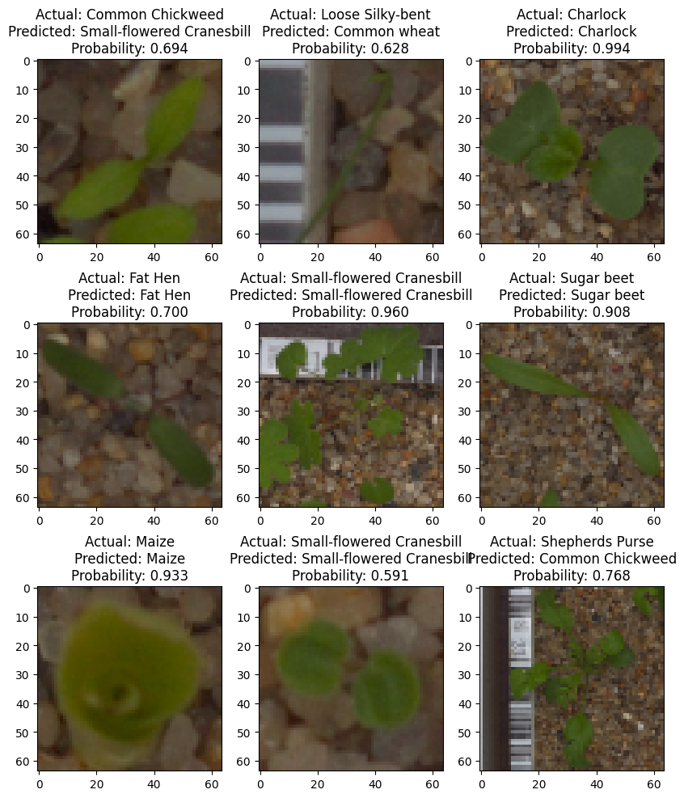

```python
# Observing the predictions by predicting rows x cols number of images
# from the test set using our final model
rows = 3
cols = 3
# Setting the figure
fig = plt.figure(figsize=(10, 12))


for i in range(cols):
  for j in range(rows):
    # Getting a random image
    random_index = np.random.randint(0, len(y_test))
    # Adjusting the subplot for the image
    ax = fig.add_subplot(rows, cols, i * rows + j + 1)
    # Shows the image
    ax.imshow(X_test[random_index])
    # Gets the label that it predicts
    pred_label = index_to_label[y_pred_test_classes[random_index]]
    # Getting the probability of the max prediction
    pred_prob  = y_pred_test_max_prob[random_index];
    # Formatting to fit the overall figure
    pred_prob = "%.3f" % pred_prob
    # Getting the label that it actually is
    true_label = index_to_label[np.argmax(y_test[random_index])]
    # # Sets the title with the true and predicted label, as well as the probability
    ax.set_title(f"Actual: {true_label}\nPredicted: {pred_label}\nProbability: {pred_prob}")

# Shows the image
plt.show()
```

**Observations:**

- Based on the amounts of time this code was executed, the model is able to predict, on average, around 6 of the 9 images correctly, putting its accuracy around 60%.
- It is important to note that in some succesful cases, the probability of the class can be as high as 1, and gets low to 0.45

Let's also observe its performance on the test set in a confusion matrix, as well as its accuracy.

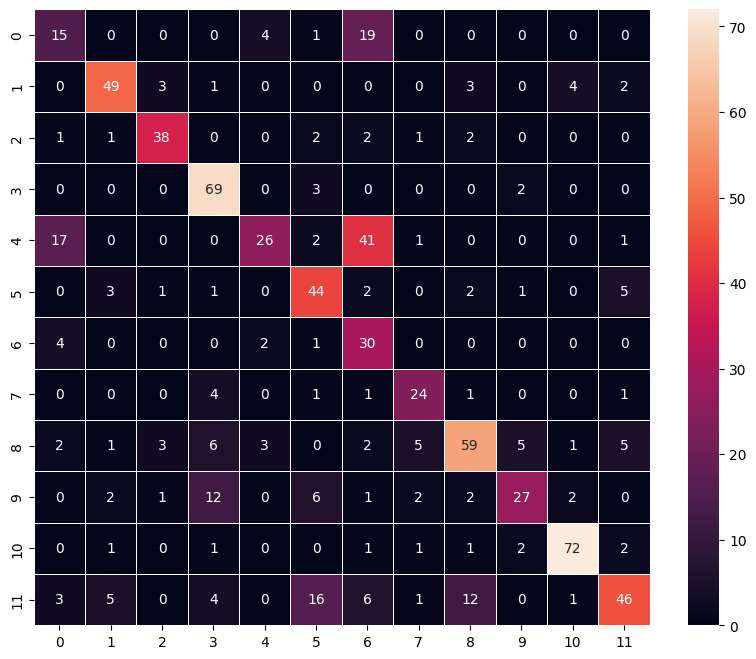

```python
# Plotting the confusion matrix
predicted = np.argmax(model_2.predict(X_test), axis=1)
target = np.argmax(y_test, axis=1)
plot_confusion_matrix(predicted, target)
```

```python
# Let's observe its performance in the test set
model_2.evaluate(X_test, y_test)
```

```
[1.0410007238388062, 0.6565789580345154]
```

**Observations:**

- Although this model had some overfitting issues, the test set shows a 65% accuracy. This is a good score, especially comparing to the other models.
  - This can also be seen in the confusion matrix as most of the numbers are located on the diagonals, proving that the model is correctly identifying the images.